# Practical 2: The brms package

Author

Benjamin Rosenbaum

We learn about the brms package and how to fit simple regression models.

Focus on: model output, convergence checks.  
Also some basic infos on priors and model predictions.

```r
rm(list=ls())
library("brms")
library("ggplot2")
library("bayesplot")
library("loo")
library("cowplot")
try(dev.off())
```

# Example 1: Linear regression

We start with our deer population and the simple weight~age example

**Question**: What’s the average growth per year? (Slope in age)

Deterministic part: $\mu=a+b\cdot age$  
Stochastic part: $weight \sim \text{Normal}(\mu,\sigma)$

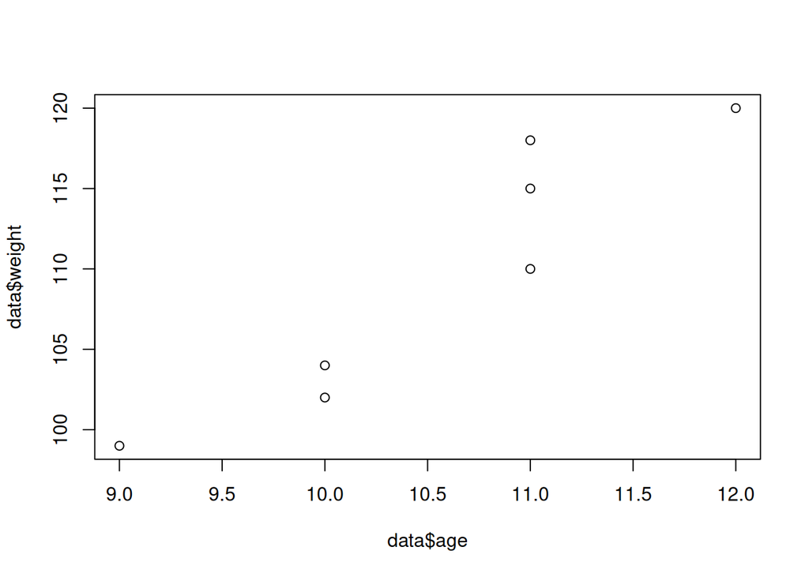

```r
data = data.frame(weight = c(104, 120, 118, 115, 99, 110, 102),
                  age    = c(10, 12, 11, 11, 9, 11, 10))
plot(data$age, data$weight)
```

## Basic brms functions

Instead of `lm()`, we use the `brm()` function. The formula notation is designed to be identical to lm, glm, lme4 (with few exceptions)

```r
fit1 = brm(weight ~ age, data=data)
```

Looking at the summary table, we get a lot of infos:

If not specified otherwise, brms uses a normal distribution for the residuals:  
`family=gaussian()`.

brms by default uses 4 chains, each with 1000 warmup and 1000 sampling iterations.  
The first thing you should look at are not parameter estimates, but Rhat and ESS.  
These indicate if the MCMC converged and the posterior distribution is properly sampled.  
Check if Rhat<1.01 and compare ESS to total number of draws.

```r
summary(fit1)
```

```
 Family: gaussian
  Links: mu = identity; sigma = identity
Formula: weight ~ age
   Data: data (Number of observations: 7)
  Draws: 4 chains, each with iter = 2000; warmup = 1000; thin = 1;
         total post-warmup draws = 4000

Regression Coefficients:
          Estimate Est.Error l-95% CI u-95% CI Rhat Bulk_ESS Tail_ESS
Intercept    25.56     21.23   -17.04    68.48 1.00     2328     1800
age           7.96      1.99     3.87    11.97 1.00     2336     1834

Further Distributional Parameters:
      Estimate Est.Error l-95% CI u-95% CI Rhat Bulk_ESS Tail_ESS
sigma     4.31      1.90     2.18     9.12 1.00     1691     2047

Draws were sampled using sampling(NUTS). For each parameter, Bulk_ESS
and Tail_ESS are effective sample size measures, and Rhat is the potential
scale reduction factor on split chains (at convergence, Rhat = 1).
```

Additionally, you should do a visual inspection of the MCMC. You get a histogram and a traceplot per parameter, which should look like a fuzzy caterpillar

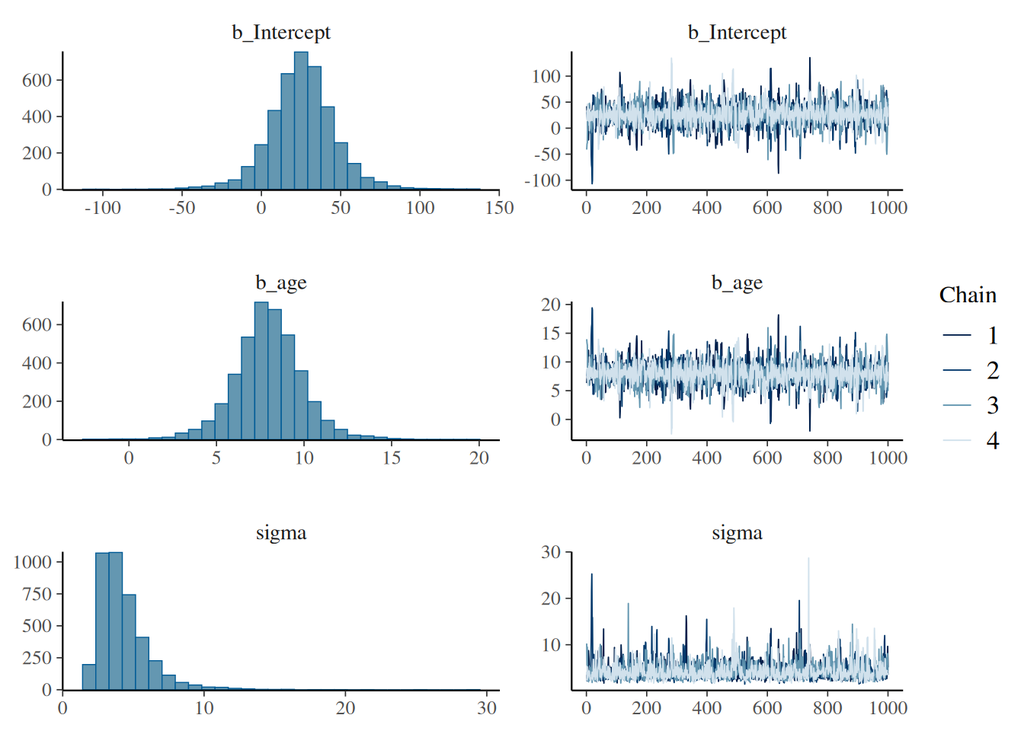

```r
plot(fit1)
```

You can change the color palette if you like

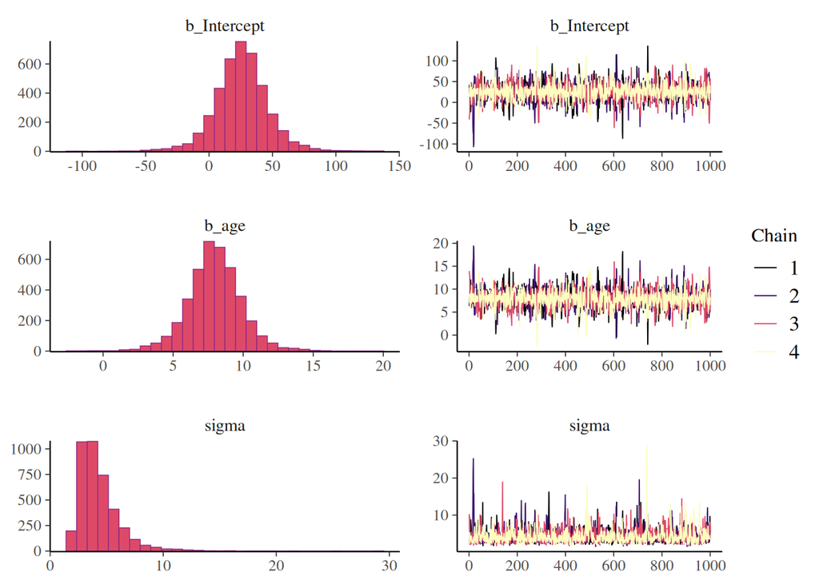

```r
color_scheme_set("viridisA")
plot(fit1)
```

and back to the default palette

```r
color_scheme_set("blue")
```

You can also specify to display just some selected parameters. Parameters of the deterministic model part begin with `b_`,the residual standard deviation is `sigma`

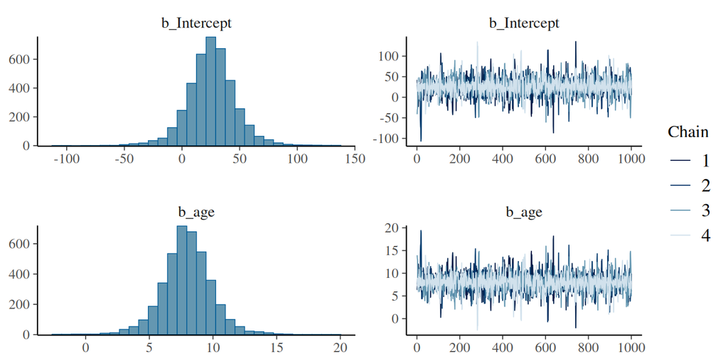

```r
plot(fit1, variable=c("b_Intercept", "b_age"))
```

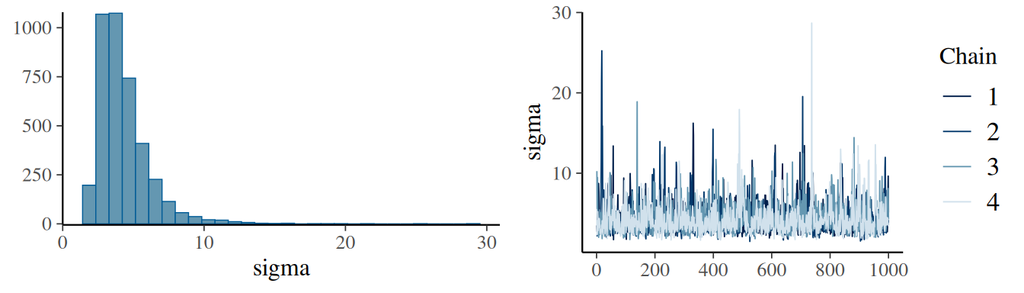

```r
plot(fit1, variable=c("sigma"))
```

Histograms and traceplots can be plotted individually

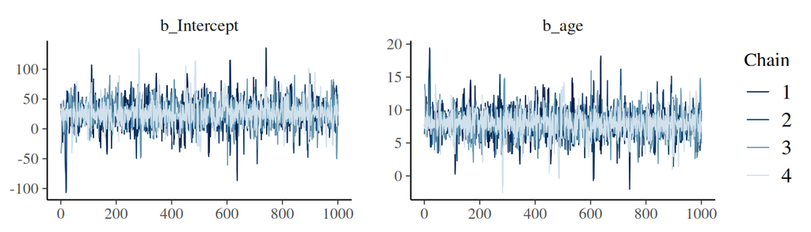

```r
mcmc_trace(fit1, pars=c("b_Intercept", "b_age"))
```

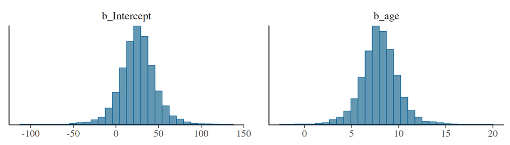

```r
mcmc_hist(fit1, pars=c("b_Intercept", "b_age"))
```

All the brms plots are done withh ggplot2, so you can extract & modify them

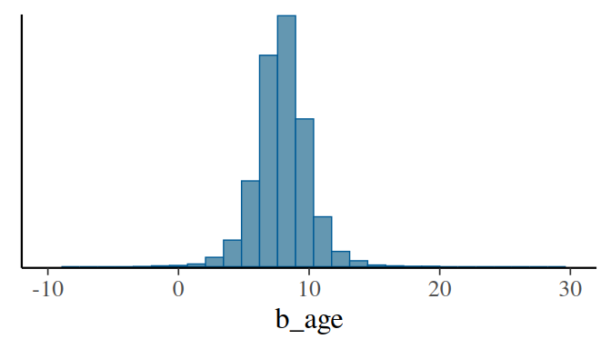

```r
plot1 = mcmc_hist(fit1, pars=c("b_age"))
plot1 + xlim(-10,30)
```

In this simple 1-predictor regression, model prediction are easily plotted vs data. `conditional_effects()` is a powerful function which we will use throughout the course.

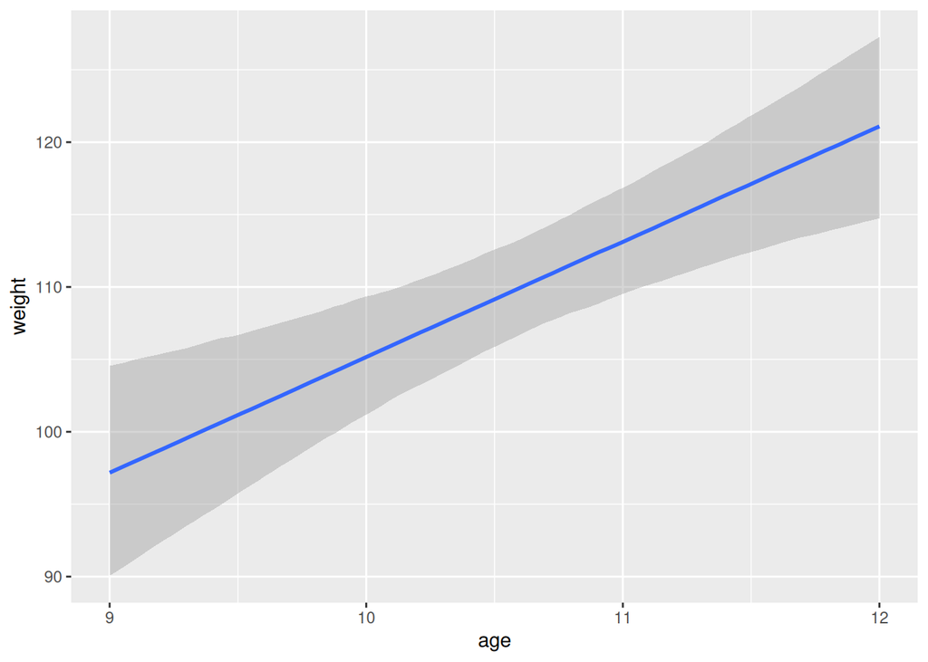

```r
plot(conditional_effects(fit1))
```

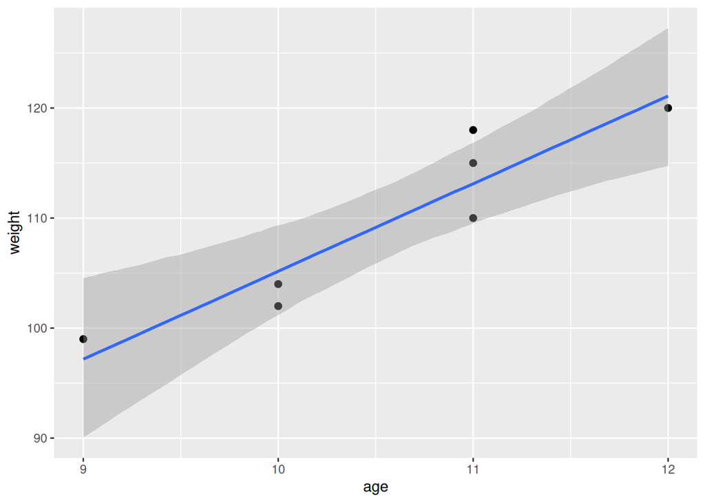

```r
plot(conditional_effects(fit1),
     points=TRUE)
```

Again, this generates a ggplot object which can be modified, with some options in the plot function, or full ggplot options if you save the object

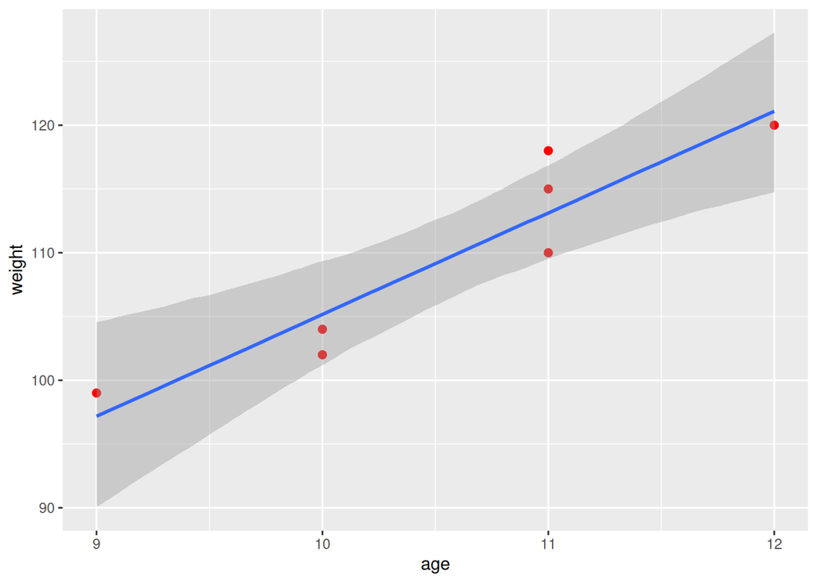

```r
plot(conditional_effects(fit1),
     points=TRUE, point_args=list(col="red"))
```

Note that we here only plot the uncertainty of the deterministic model part mu, more on that tomorrow. `fitted()` computes predictions of mu for each datapoint.

```r
fitted(fit1) |> head()
```

```
      Estimate Est.Error      Q2.5    Q97.5
[1,] 105.18401  2.084831 101.18471 109.3446
[2,] 121.10918  3.186816 114.74524 127.2614
[3,] 113.14659  1.813679 109.52796 116.8500
[4,] 113.14659  1.813679 109.52796 116.8500
[5,]  97.22142  3.650626  90.06248 104.5488
[6,] 113.14659  1.813679 109.52796 116.8500
```

The brms package does not only offer model fitting via MCMC, it also has a lot of functions for model analysis and is compatible with a lot of other packages (e.g. emmeans). We will learn about some of these in the next days.

```r
methods(class="brmsfit")
```

```
 [1] add_criterion           add_ic                  as_draws_array          as_draws_df             as_draws_list           as_draws_matrix         as_draws_rvars          as_draws
 [9] as.array                as.data.frame           as.matrix               as.mcmc                 autocor                 bayes_factor            bayes_R2                bridge_sampler
[17] coef                    conditional_effects     conditional_smooths     control_params          default_prior           expose_functions        family                  fitted
[25] fixef                   formula                 getCall                 hypothesis              kfold                   log_lik                 log_posterior           logLik
[33] loo_compare             loo_epred               loo_linpred             loo_model_weights       loo_moment_match        loo_predict             loo_predictive_interval loo_R2
[41] loo_subsample           loo                     LOO                     marginal_effects        marginal_smooths        mcmc_plot               model_weights           model.frame
[49] nchains                 ndraws                  neff_ratio              ngrps                   niterations             nobs                    nsamples                nuts_params
[57] nvariables              pairs                   parnames                plot                    post_prob               posterior_average       posterior_epred         posterior_interval
[65] posterior_linpred       posterior_predict       posterior_samples       posterior_smooths       posterior_summary       pp_average              pp_check                pp_mixture
[73] predict                 predictive_error        predictive_interval     prepare_predictions     print                   prior_draws             prior_summary           psis
[81] ranef                   reloo                   residuals               restructure             rhat                    stancode                standata                stanplot
[89] summary                 update                  VarCorr                 variables               vcov                    waic                    WAIC
see '?methods' for accessing help and source code
```

## brms specifications & priors

When we compare the results to frequentist lm-model, the slope is pretty close but there’s ~0.5 difference in intercepts.

```r
fixef(fit1)
```

```
           Estimate Est.Error       Q2.5    Q97.5
Intercept 25.558166 21.229873 -17.041362 68.47664
age        7.962584  1.990409   3.872543 11.97261
```

```r
lm(weight ~ age, data=data) |> coef()
```

```
(Intercept)         age
       26.2         7.9
```

So why are they different? What about priors, did we specify any?

The `brm()` function has **A TON OF** specifications, which we did not specify in the simple `brm(weight~age, data=data)` model, see the help function with `?brm`. So brms uses default values.

```r
?brm
```

E.g., we can specify the number of chains & iterations manually. Per default, half of the iterations are used for warmup and are discared from the posterior sample.

```r
fit2 = brm(weight ~ age,
           data = data,
           chains = 4,
           iter = 5000
)
```

With a larger number of samples (`iter`), we expect a more accurate approximation of the true posterior. Parameter means usually are quite correct even for low numbers, while outer quantiles (e.g. 90%, 95%) require larger numbers of samples.

```r
summary(fit2)
```

```
 Family: gaussian
  Links: mu = identity; sigma = identity
Formula: weight ~ age
   Data: data (Number of observations: 7)
  Draws: 4 chains, each with iter = 5000; warmup = 2500; thin = 1;
         total post-warmup draws = 10000

Regression Coefficients:
          Estimate Est.Error l-95% CI u-95% CI Rhat Bulk_ESS Tail_ESS
Intercept    26.25     21.61   -17.79    68.66 1.00     5245     4110
age           7.89      2.04     3.94    12.02 1.00     5257     4131

Further Distributional Parameters:
      Estimate Est.Error l-95% CI u-95% CI Rhat Bulk_ESS Tail_ESS
sigma     4.30      1.87     2.13     9.10 1.00     3621     3481

Draws were sampled using sampling(NUTS). For each parameter, Bulk_ESS
and Tail_ESS are effective sample size measures, and Rhat is the potential
scale reduction factor on split chains (at convergence, Rhat = 1).
```

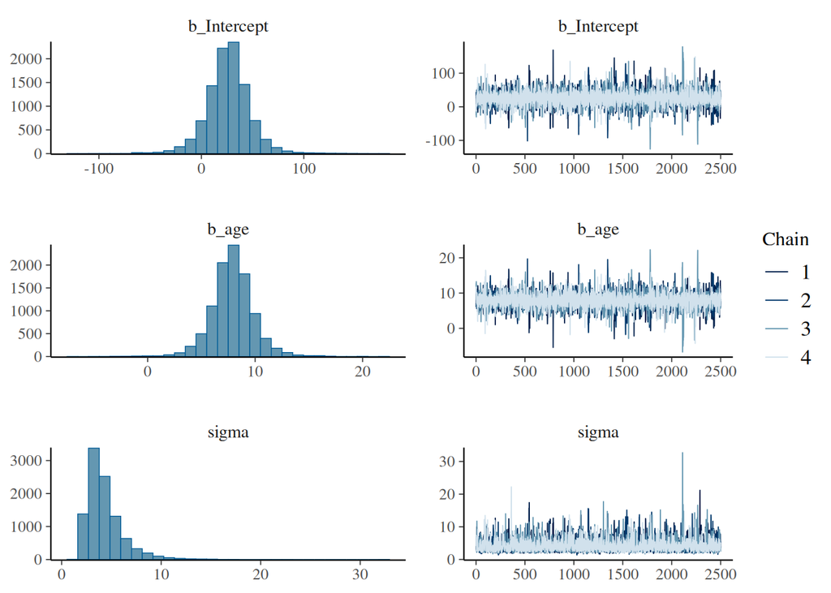

```r
plot(fit2)
```

We can check the defaults for any model with `default_prior()`. The model does not have to be fitted, just model formula and data must be specified.

```r
default_prior(weight ~ age,
              data = data)
```

```
                   prior     class coef group resp dpar nlpar lb ub       source
                  (flat)         b                                       default
                  (flat)         b  age                             (vectorized)
 student_t(3, 110, 11.9) Intercept                                       default
   student_t(3, 0, 11.9)     sigma                             0         default
```

Alternatively, you can display the priors of any fitted model. Since we had not specified any priors, both outputs are the same here.

```r
prior_summary(fit2)
```

```
                   prior     class coef group resp dpar nlpar lb ub       source
                  (flat)         b                                       default
                  (flat)         b  age                             (vectorized)
 student_t(3, 110, 11.9) Intercept                                       default
   student_t(3, 0, 11.9)     sigma                             0         default
```

This table can be a bit confusing, but look at the column `class`: `b` is for effects / slopes. The first line tells you if there is a prior used for ALL effects, which is not the case (`prior=flat`). Second line is the prior for a specific coefficient (`coef=age`), there’s also no prior specified.

But brms chooses a prior for `Intercept` and for the residual sdev `sigma`. These are automatically generated from the mean and the spread of the response. Note that internally, the brms machine uses mean-centered predictors. The `Intercept` parameter (and its prior) are based on mean-centered variables. What’s displayed in the model summary is actually `b_Intercept` which is the intercept parameter transformed to the original, non mean-centered scale.

A short form is presented in the summary for prior=TRUE

```r
summary(fit2, prior=TRUE)
```

```
 Family: gaussian
  Links: mu = identity; sigma = identity
Formula: weight ~ age
   Data: data (Number of observations: 7)
  Draws: 4 chains, each with iter = 5000; warmup = 2500; thin = 1;
         total post-warmup draws = 10000

Priors:
Intercept ~ student_t(3, 110, 11.9)
<lower=0> sigma ~ student_t(3, 0, 11.9)

Regression Coefficients:
          Estimate Est.Error l-95% CI u-95% CI Rhat Bulk_ESS Tail_ESS
Intercept    26.25     21.61   -17.79    68.66 1.00     5245     4110
age           7.89      2.04     3.94    12.02 1.00     5257     4131

Further Distributional Parameters:
      Estimate Est.Error l-95% CI u-95% CI Rhat Bulk_ESS Tail_ESS
sigma     4.30      1.87     2.13     9.10 1.00     3621     3481

Draws were sampled using sampling(NUTS). For each parameter, Bulk_ESS
and Tail_ESS are effective sample size measures, and Rhat is the potential
scale reduction factor on split chains (at convergence, Rhat = 1).
```

Unless necessary, I would leave the brms defaults for `Intercept` & `sigma`. However, you should choose a prior for the slope, which currently has none.

This would set a prior for all slopes (if you have >1 predictors)

```r
my_priors = prior(normal(5,1), class=b)
```

For setting a prior for a specific predictor, you specify it in `coef`. Since this model only has 1 predictor, both formulations are the same.

```r
my_priors = prior(normal(5,1), class=b, coef=age)
```

```r
fit3 = brm(weight ~ age,
           prior = my_priors,
           data = data,
           chains = 4,
           iter = 5000
)
```

```r
summary(fit3, prior=TRUE)
```

```
 Family: gaussian
  Links: mu = identity; sigma = identity
Formula: weight ~ age
   Data: data (Number of observations: 7)
  Draws: 4 chains, each with iter = 5000; warmup = 2500; thin = 1;
         total post-warmup draws = 10000

Priors:
b_age ~ normal(5, 1)
Intercept ~ student_t(3, 110, 11.9)
<lower=0> sigma ~ student_t(3, 0, 11.9)

Regression Coefficients:
          Estimate Est.Error l-95% CI u-95% CI Rhat Bulk_ESS Tail_ESS
Intercept    49.08     10.00    30.68    69.54 1.00     6562     6790
age           5.74      0.93     3.84     7.48 1.00     6627     6763

Further Distributional Parameters:
      Estimate Est.Error l-95% CI u-95% CI Rhat Bulk_ESS Tail_ESS
sigma     4.59      1.75     2.36     9.06 1.00     4814     5306

Draws were sampled using sampling(NUTS). For each parameter, Bulk_ESS
and Tail_ESS are effective sample size measures, and Rhat is the potential
scale reduction factor on split chains (at convergence, Rhat = 1).
```

We can draw prior & posterior in 1 plot by using `mcmc_dens` to plot the posterior distribution and adding the prior distribution (which we specified with `normal(5,1)` earlier). We also draw the old posterior without a slope-prior for comparison

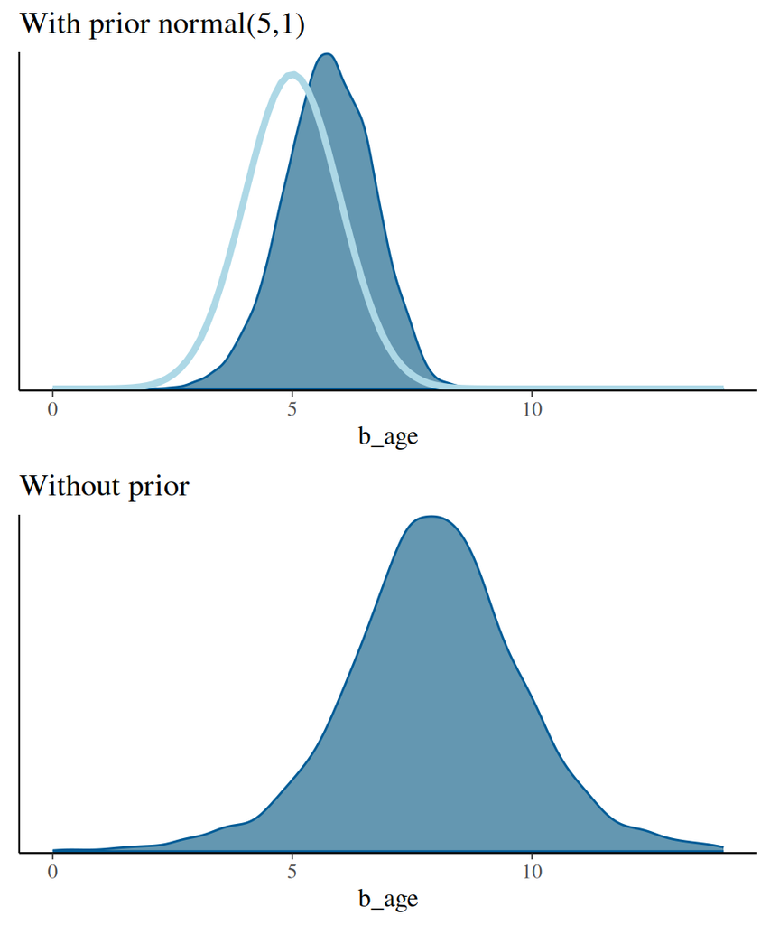

```r
plot3 = mcmc_dens(fit3, pars=c("b_age"))
plot3 = plot3 +
  geom_function(fun=dnorm, args=list(mean=5, sd=1), colour="lightblue", linewidth=1.5) +
  xlim(0,14) +
  ggtitle("With prior normal(5,1)")

plot1 = mcmc_dens(fit1, pars=c("b_age"))
plot1 = plot1 +
  xlim(0,14) +
  ggtitle("Without prior")

plot_grid(plot3, plot1, nrow=2)
```

Here we only have a small dataset and an informative prior (mean=5) changes the posterior estimate of the slope.

## Model analysis

Only after we checked MCMC convergence, we can go to the next step: Model evaluation / model checking. How well does our model describe the data?

A classical visual tool is observed vs predicted, which also works if you have multiple predictors.

```
Using all posterior draws for ppc type 'scatter_avg' by default.
```

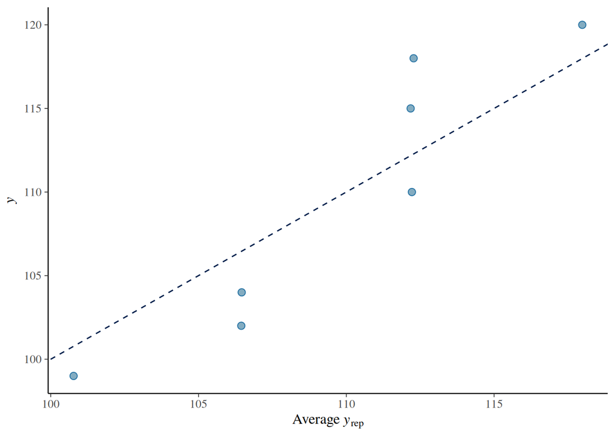

```r
pp_check(fit3, "scatter_avg")
```

`bayes_R2` is the amount of explained variation. Its computation is a bit different from the classical frequentist R2, but conceptually it means the same.

```r
bayes_R2(fit3)
```

```
   Estimate Est.Error      Q2.5     Q97.5
R2 0.680979  0.129089 0.3647646 0.8557636
```

More on that tomorrow, e.g. checking model assumptions.

## Inference

OK, so we know that (a) MCMC converged and (b) model describes the data well. Only now can we make inference, i.e. quantitative statements about research questions. The summary already tells us mean and 95% confidence intervals for the slope (growth per year of age).

Different Credible intervals can be chosen in the summary, e.g. 90%-CI. 90% of posterior samples for slope were in this interval, we are 90% sure that the slope is in this interval.

```r
summary(fit3, prob=0.90)
```

```
 Family: gaussian
  Links: mu = identity; sigma = identity
Formula: weight ~ age
   Data: data (Number of observations: 7)
  Draws: 4 chains, each with iter = 5000; warmup = 2500; thin = 1;
         total post-warmup draws = 10000

Regression Coefficients:
          Estimate Est.Error l-90% CI u-90% CI Rhat Bulk_ESS Tail_ESS
Intercept    49.08     10.00    33.04    65.99 1.00     6562     6790
age           5.74      0.93     4.16     7.24 1.00     6627     6763

Further Distributional Parameters:
      Estimate Est.Error l-90% CI u-90% CI Rhat Bulk_ESS Tail_ESS
sigma     4.59      1.75     2.56     7.96 1.00     4814     5306

Draws were sampled using sampling(NUTS). For each parameter, Bulk_ESS
and Tail_ESS are effective sample size measures, and Rhat is the potential
scale reduction factor on split chains (at convergence, Rhat = 1).
```

Or you can extract specific quantiles of parameter estimates. `fixef` means “fixed effects” here.

```r
fixef(fit3)
```

```
           Estimate Est.Error      Q2.5     Q97.5
Intercept 49.079222 9.9968130 30.675897 69.541695
age        5.741318 0.9277682  3.842057  7.475878
```

```r
fixef(fit3, probs=c(0.25, 0.5, 0.75))
```

```
           Estimate Est.Error       Q25       Q50       Q75
Intercept 49.079222 9.9968130 42.043930 48.890111 55.640038
age        5.741318 0.9277682  5.127492  5.761661  6.395498
```

In a frequentist analysis you would want to know if the effect of age is “significant”:  
p-values quantify the probability of observing such a pattern the data if the null hypothesis (b_age=0) was true (p small -> reject H0).

Here, we can just calculate the probability that the slope is positive, $P(b\_age>0)$, with the `hypothesis` function. The column `Post.Prob` is the value of interest. It’s =1 because all samples of slope were positive

```r
hypothesis(fit3, "age>0")
```

```
Hypothesis Tests for class b:
  Hypothesis Estimate Est.Error CI.Lower CI.Upper Evid.Ratio Post.Prob Star
1  (age) > 0     5.74      0.93     4.16     7.24        Inf         1    *
---
'CI': 90%-CI for one-sided and 95%-CI for two-sided hypotheses.
'*': For one-sided hypotheses, the posterior probability exceeds 95%;
for two-sided hypotheses, the value tested against lies outside the 95%-CI.
Posterior probabilities of point hypotheses assume equal prior probabilities.
```

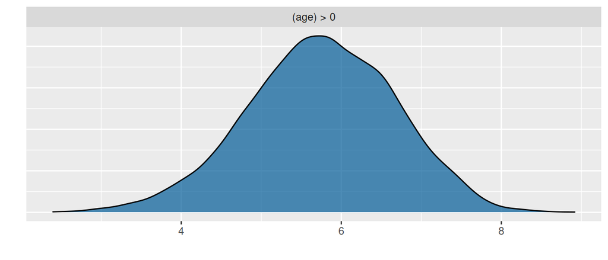

```r
plot(hypothesis(fit3, "age>0"))
```

You can test all kinds of hypotheses for the parameters! If we were interested in the question if growth per year is bigger than 4, $P(b\_age>4)$, just put it in the hypothesis. The function is quite powerful and can handle all kinds of transformations of parameters.

```r
hypothesis(fit3, "age>4")
```

```
Hypothesis Tests for class b:
     Hypothesis Estimate Est.Error CI.Lower CI.Upper Evid.Ratio Post.Prob Star
1 (age)-(4) > 0     1.74      0.93     0.16     3.24      27.01      0.96    *
---
'CI': 90%-CI for one-sided and 95%-CI for two-sided hypotheses.
'*': For one-sided hypotheses, the posterior probability exceeds 95%;
for two-sided hypotheses, the value tested against lies outside the 95%-CI.
Posterior probabilities of point hypotheses assume equal prior probabilities.
```

It’s transformed in the equivalent formulation `age-4>0`, and this is the probability distribution which is actually plotted.

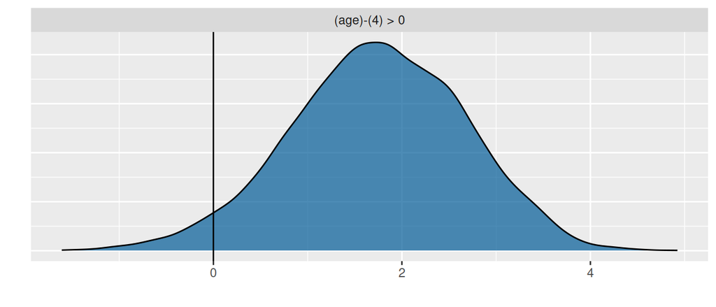

```r
plot1 = plot(hypothesis(fit3, "age>4"), plot=FALSE)
plot1[[1]] + geom_vline(xintercept=0)
```

The posterior probability is 0.96, which is also the integral (area under the curve) right of zero (`age-4>0`)

# Exercise 1: Survival rate

Population counts from different habitats before and after winter.

**Question**: Is the average survival rate bigger than 2/3 ?

Deterministic part: $\mu=\theta$, $\theta\in[0,1]$  
Stochastic part: $survived_i \sim \text{Binomial}(total_i,\mu)$

Check the default prior!

Choose a meaningful prior for the `Intercept` parameter, use `lb=0`, `ub=1`.  
Fit the model & verify convergence.  
Re-run the analysis for different priors.

```r
data = data.frame(total    = c(22,22,29,21,25,30,24,23,25,28),
                  survived = c(19,14,23,19,20,18,15,16,18,15))

default_prior(survived | trials(total) ~ 1,
              family = binomial(link="identity"),
              data = data)
```

```
Intercept ~ student_t(3, 18, 3)
```

This brms default prior choice does not make any sense (mean=18), since it is chosen from the mean of the response `survived` (I guess??), while the parameter is actually a rate / probability $0<\theta<1$. Here brms messed up because we have overwritten the default link=“logit” of the binomial distribution (again, I guess??). In most cases the default prior is fine, but better check it for generalized linear models (see also part 5 on GLMs).

We use 3 different beta distribution priors (defined on interval [0,1]). Two shape parameters $s_1,s_2$ describe concentration to its mean $s_1/(s_1+s_2)$  
(1) beta(1,1) = uniform distribution  
(2) beta(2,2) = weak prior, mean=0.5  
(3) beta(20,20) = informative prior, mean=0.5

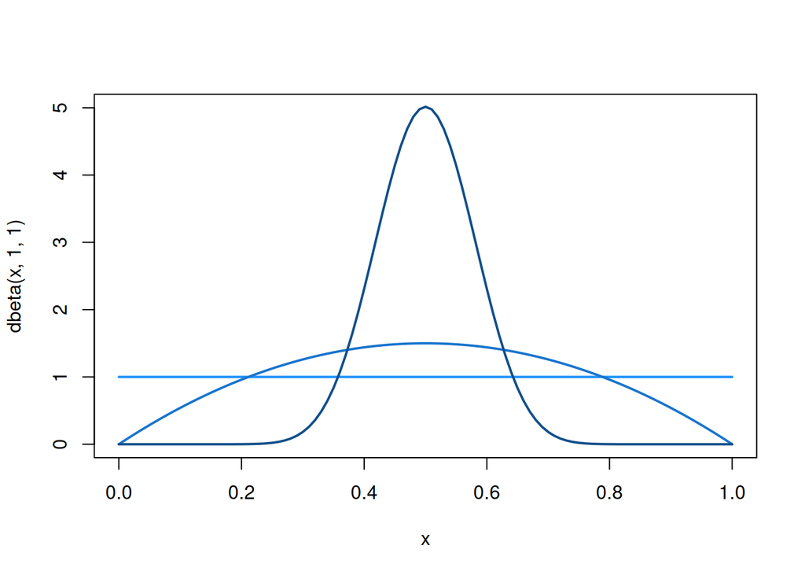

```r
curve(dbeta(x,1,1), ylim=c(0,5), col="dodgerblue", lwd=2)
curve(dbeta(x,2,2), add=TRUE, col="dodgerblue3", lwd=2)
curve(dbeta(x,20,20), add=TRUE, , col="dodgerblue4", lwd=2)
```

```r
fit4 = brm(survived | trials(total) ~ 1,
           family = binomial(link="identity"),
           prior = prior(uniform(0,1), class=Intercept, lb=0, ub=1),
           data = data)
```

```r
fit5 = brm(survived | trials(total) ~ 1,
           family = binomial(link="identity"),
           prior = prior(beta(2,2), class=Intercept, lb=0, ub=1),
           data = data)
```

```r
fit6 = brm(survived | trials(total) ~ 1,
           family = binomial(link="identity"),
           prior = prior(beta(20,20), class=Intercept, lb=0, ub=1),
           data = data)
```

```r
summary(fit4)
```

```
 Family: binomial
  Links: mu = identity
Formula: survived | trials(total) ~ 1
   Data: data (Number of observations: 10)
  Draws: 4 chains, each with iter = 2000; warmup = 1000; thin = 1;
         total post-warmup draws = 4000

Regression Coefficients:
          Estimate Est.Error l-95% CI u-95% CI Rhat Bulk_ESS Tail_ESS
Intercept     0.71      0.03     0.65     0.77 1.00     1518     1824

Draws were sampled using sampling(NUTS). For each parameter, Bulk_ESS
and Tail_ESS are effective sample size measures, and Rhat is the potential
scale reduction factor on split chains (at convergence, Rhat = 1).
```

Here, the prior has only little effect on the outcome:

```r
fixef(fit4)
```

```
          Estimate  Est.Error      Q2.5     Q97.5
Intercept 0.708836 0.02882774 0.6515685 0.7655459
```

```r
fixef(fit5)
```

```
           Estimate  Est.Error      Q2.5     Q97.5
Intercept 0.7077716 0.02844394 0.6496433 0.7619462
```

```r
fixef(fit6)
```

```
           Estimate  Est.Error      Q2.5     Q97.5
Intercept 0.6818631 0.02743494 0.6242358 0.7356291
```

Plot prior & posterior for the different models:

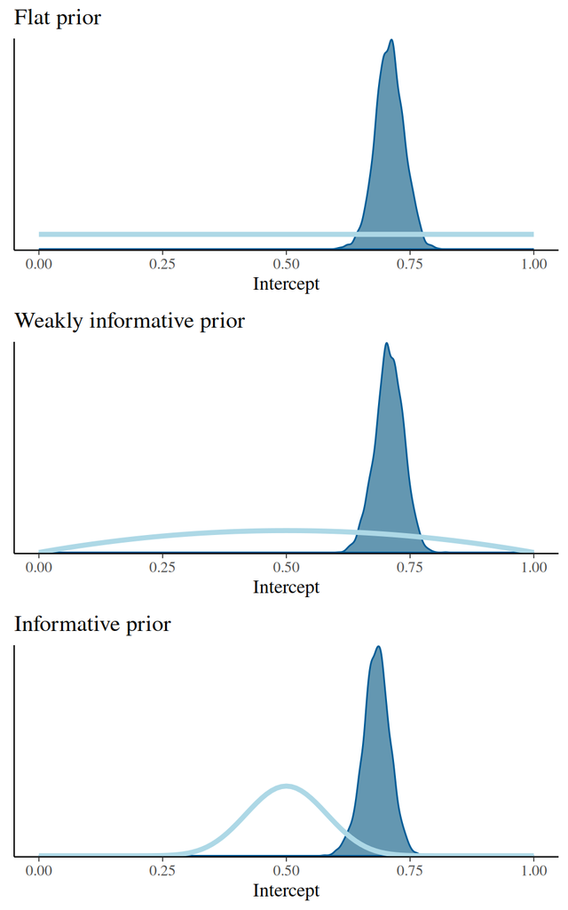

```r
plot1 = mcmc_dens(fit4, pars=c("Intercept"))
plot1 = plot1 +
  geom_function(fun=dbeta, args=list(1, 1), colour="lightblue", linewidth=1.5) +
  xlim(0,1) +
  ggtitle("Flat prior")

plot2 = mcmc_dens(fit5, pars=c("Intercept"))
plot2 = plot2 +
  geom_function(fun=dbeta, args=list(2, 2), colour="lightblue", linewidth=1.5) +
  xlim(0,1) +
  ggtitle("Weakly informative prior")

plot3 = mcmc_dens(fit6, pars=c("Intercept"))
plot3 = plot3 +
  geom_function(fun=dbeta, args=list(20, 20), colour="lightblue", linewidth=1.5) +
  xlim(0,1) +
  ggtitle("Informative prior")

plot_grid(plot1, plot2, plot3, nrow=3)
```

We use the weakly informative prior model to test is survival rate is >2/3

```r
hypothesis(fit5, "Intercept>2/3")
```

```
Hypothesis Tests for class b:
             Hypothesis Estimate Est.Error CI.Lower CI.Upper Evid.Ratio Post.Prob Star
1 (Intercept)-(2/3) > 0     0.04      0.03    -0.01     0.09      11.31      0.92
---
'CI': 90%-CI for one-sided and 95%-CI for two-sided hypotheses.
'*': For one-sided hypotheses, the posterior probability exceeds 95%;
for two-sided hypotheses, the value tested against lies outside the 95%-CI.
Posterior probabilities of point hypotheses assume equal prior probabilities.
```

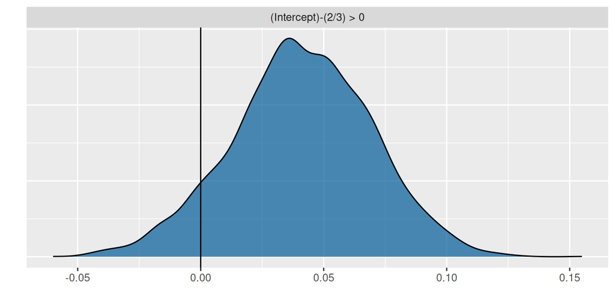

```r
plot1 = plot(hypothesis(fit5, "Intercept>2/3"), plot=FALSE)
plot1[[1]] + geom_vline(xintercept=0)
```

We estimate a mean survival rate of 0.708 with a 95% credible interval [0.649,0.762]. Also, posterior probability $P(\theta>2/3)=0.92$, which means we are only 92% certain that average survival rate is larger than 2/3.